# Lista05_MQ101_CerveraCelia

Celia Cervera Callacná - 21202521058

17/12/2025

```r
library(tidyverse)
library(broom)

set.seed(123)
```

# Geração da base de dados fictícia

```r
n <- 400

dados <- tibble(
  id        = 1:n,
  idade     = round(rnorm(n, mean = 40, sd = 12)),
  sexo      = sample(c("F", "M"), n, replace = TRUE, prob = c(0.55, 0.45)),
  renda     = round(rlnorm(n, meanlog = log(2500), sdlog = 0.5), 0),
  escolarid = sample(c("fundamental", "medio", "superior"),
                     n, replace = TRUE, prob = c(0.30, 0.40, 0.30)),
  ideologia = round(runif(n, 0, 10), 0),   # 0 = esquerda, 10 = direita
  apoio_gov = rbinom(n, 1, plogis(-1 + 0.015*(idade - 40) +
                                    0.4*(sexo == "F") +
                                    0.5*(renda > 3000))),
  satisf_gov = pmin(pmax(
    round(3 + 2*apoio_gov + 0.001*(renda - 2500) +
            rnorm(n, 0, 2), 0), 0), 10),

  # 0 = não participou, 1 = participou de protestos

  protesto = rbinom(n, 1, plogis(-2 + 0.3*(ideologia <= 4) - 0.2*apoio_gov))
)

glimpse(dados)
```

```
## Rows: 400
## Columns: 9
## $ id         <int> 1, 2, 3, 4, 5, 6, 7, 8, 9, 10, 11, 12, 13, 14, 15, 16, 17, …
## $ idade      <dbl> 33, 37, 59, 41, 42, 61, 46, 25, 32, 35, 55, 44, 45, 41, 33,…
## $ sexo       <chr> "F", "F", "F", "F", "F", "M", "F", "F", "M", "M", "F", "M",…
## $ renda      <dbl> 4277, 2466, 2459, 1171, 3712, 2250, 1800, 1234, 2152, 1635,…
## $ escolarid  <chr> "medio", "medio", "medio", "superior", "superior", "superio…
## $ ideologia  <dbl> 7, 6, 2, 9, 8, 3, 2, 7, 7, 5, 9, 7, 2, 0, 9, 1, 3, 4, 6, 3,…
## $ apoio_gov  <int> 0, 0, 0, 0, 1, 0, 0, 1, 0, 1, 1, 0, 1, 1, 1, 0, 0, 1, 0, 1,…
## $ satisf_gov <dbl> 4, 4, 2, 0, 3, 2, 7, 6, 6, 6, 7, 4, 9, 4, 6, 0, 2, 6, 4, 8,…
## $ protesto   <int> 0, 0, 0, 0, 0, 0, 1, 0, 0, 1, 0, 1, 0, 0, 0, 1, 1, 0, 0, 0,…
```

# EXERCICIO 1 – Exploração descritiva e gráficos básicos

```r
#média, mediana, desvio-padrão e quartis de idade, renda e satisf_gov

summary(dados$idade)
```

```
##    Min. 1st Qu.  Median    Mean 3rd Qu.    Max.
##    10.0    33.0    40.0    40.2    48.0    79.0
```

```r
sd(dados$idade, na.rm = TRUE)
```

```
## [1] 11.63932
```

```r
quantile(dados$idade, probs = c(0.25, 0.5, 0.75), na.rm = TRUE)
```

```
## 25% 50% 75%
##  33  40  48
```

```r
summary(dados$renda)
```

```
##    Min. 1st Qu.  Median    Mean 3rd Qu.    Max.
##     681    1772    2504    2867    3466    9604
```

```r
sd(dados$renda, na.rm = TRUE)
```

```
## [1] 1588.662
```

```r
quantile(dados$renda, probs = c(0.25, 0.5, 0.75), na.rm = TRUE)
```

```
##     25%     50%     75%
## 1771.75 2503.50 3466.25
```

```r
summary(dados$satisf_gov)
```

```
##    Min. 1st Qu.  Median    Mean 3rd Qu.    Max.
##   0.000   2.000   4.000   4.263   6.000  10.000
```

```r
sd(dados$satisf_gov, na.rm = TRUE)
```

```
## [1] 2.723442
```

```r
quantile(dados$satisf_gov, probs = c(0.25, 0.5, 0.75), na.rm = TRUE)
```

```
## 25% 50% 75%
##   2   4   6
```

```r
#proporção de respondentes por categoria de sexo e escolaride

prop.table(table(dados$sexo))
```

```
##
##    F    M
## 0.55 0.45
```

```r
prop.table(table(dados$escolarid))
```

```
##
## fundamental       medio    superior
##      0.2975      0.4050      0.2975
```

```r
#proporção de respondentes com apoio_gov = 1

mean(dados$apoio_gov == 1, na.rm = TRUE)
```

```
## [1] 0.375
```

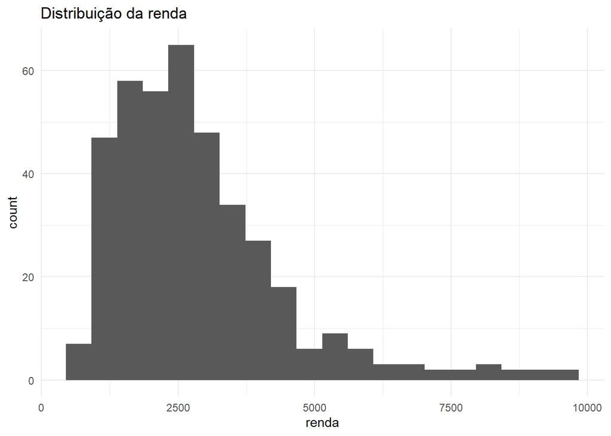

```r
#construa os seguintes gráficos

#um histograma de renda (use pelo menos 20 quebras)
ggplot(dados, aes(x = renda)) +
  geom_histogram(bins = 20) +
   labs(
    title = "Distribuição da renda",
    ) +
  theme_minimal()
```

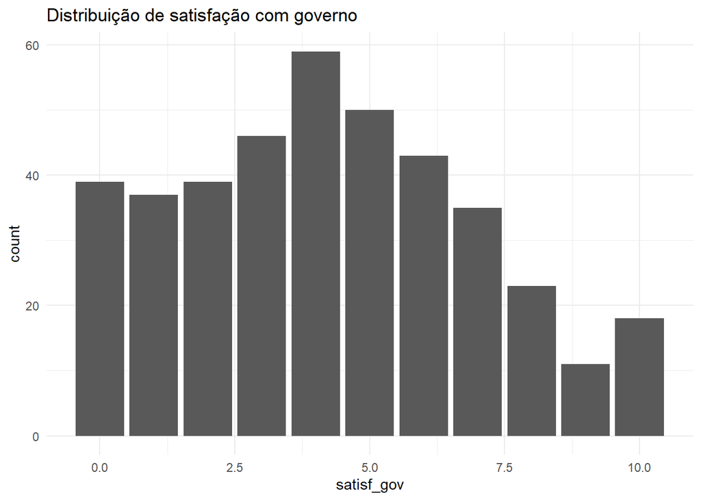

```r
#A distribuição de renda está concentrada em valores inferiores a 3.000 reais,
#portanto é assimétrica.

#um histograma ou gráfico de barras da distribuição de satisf_gov
ggplot(dados, aes(x = satisf_gov)) +
  geom_bar()+
   labs(
    title = "Distribuição de satisfação com governo",
    ) +
  theme_minimal()
```

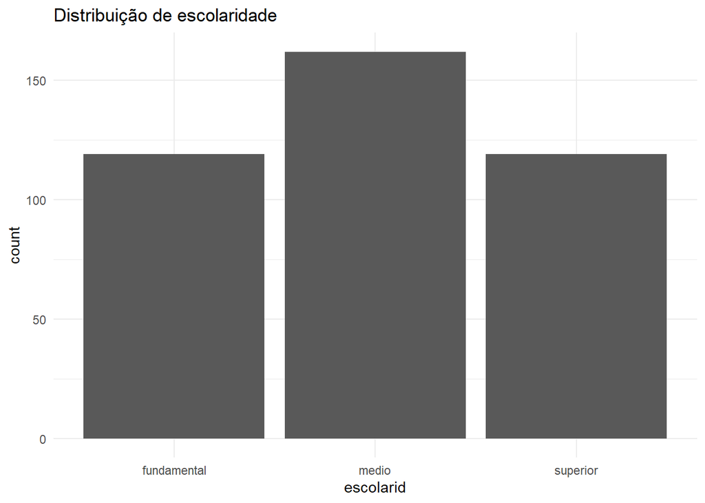

```r
#Os valores de satisfação estão concentrados no meio.

#um gráfico de barras com a distribuição de escolarid
ggplot(dados, aes(x = escolarid)) +
  geom_bar()+
   labs(
    title = "Distribuição de escolaridade",
    ) +
  theme_minimal()
```

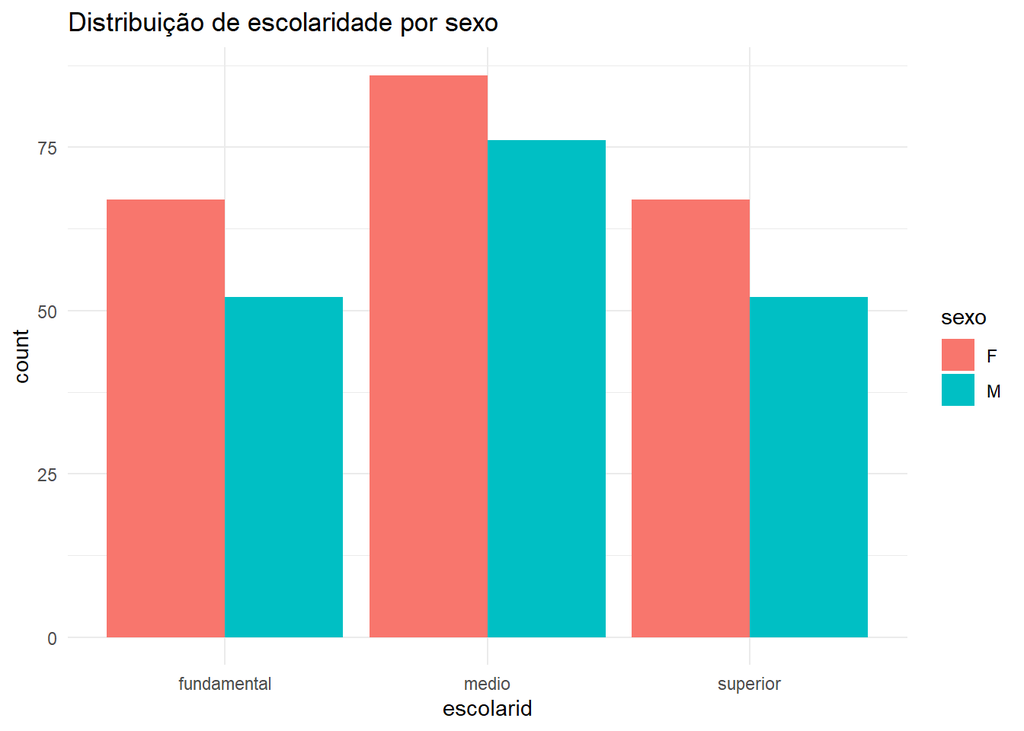

```r
ggplot(dados, aes(x = escolarid, fill = sexo)) +
  geom_bar(position = "dodge")+
   labs(
    title = "Distribuição de escolaridade por sexo",
    ) +
  theme_minimal()
```

# EXERCICIO 2:

### a) sexo (F/M) e apoio_gov (0/1)- categórico

```
    X (sexo): qualitativa categórica (duas categorias: F/M)
    Y (apoio_gov): qualitativa categórica binária (0/1)
    Teste sugerido: Tabela / Qui-quadrado
```

### b) escolarid (3 categorias) e apoio_gov (0/1).

```
    X (escolarid): qualitativa categórica (três categorias)
    Y (apoio_gov): qualitativa categórica binária (0/1)
    Teste sugerido: Tabela / Qui-quadrado
```

### c) satisf_gov (0–10) e apoio_gov (0/1)

```
    X (satisf_gov): quantitativa discreta (escala de 0 a 10)
    Y (apoio_gov): qualitativa categórica binária (0/1)
    Teste sugerido: Diferença de médias
```

### d) satisf_gov (0–10) e renda (contínua)

```
    X (satisf_gov): quantitativa discreta (escala de 0 a 10)
    Y (renda): quantitativa contínua
    Teste sugerido: Correlação ou regressão simple.
```

### e) satisf_gov (0–10) e ideologia (0–10)

```
    X (satisf_gov): quantitativa discreta (escala de 0 a 10)
    Y (ideologia): quantitativa discreta (escala de 0 a 10)
    Teste sugerido: Correlação ou regressão simple.
```

# EXERCICIO 3 - Test Qui-quadrado

```r
tab_sexo_apoio <- table(dados$sexo, dados$apoio_gov)
tab_sexo_apoio
```

```
##
##       0   1
##   F 142  78
##   M 108  72
```

```r
prop.table(tab_sexo_apoio, margin = 2)
```

```
##
##         0     1
##   F 0.568 0.520
##   M 0.432 0.480
```

### H0: não há associação entre sexo e apoio_gov na população;

### H1: há associação entre sexo e apoio_gov.

## Test Qui-quadrado

```r
chisq.test(tab_sexo_apoio)
```

```
##
##  Pearson's Chi-squared test with Yates' continuity correction
##
## data:  tab_sexo_apoio
## X-squared = 0.68956, df = 1, p-value = 0.4063
```

O valor do qui-quadrado é 0,68956. O grau de liberdade é 1. O valor do p-value = 0.4063, por tanto o valor não é significativo. Não se rejeita Ho, então aceitamos que não há evidência estatisticamente significativa de que o apoio ao governo depende do sexo.

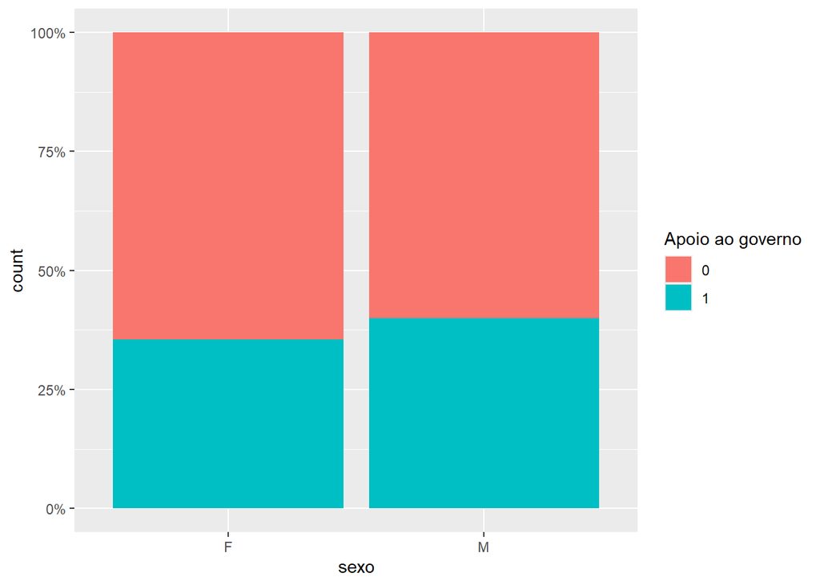

```r
ggplot(dados, aes(x = sexo, fill = factor(apoio_gov))) +
  geom_bar(position = "fill") +
  scale_y_continuous(labels = scales::percent) +
  labs(fill = "Apoio ao governo")
```

O padrão visual é coerente com o resultado do teste, pois em ambas as categorias há uma porcentagem semelhante de pessoas que não aprovam o governo.

# EXERCICIO 4 – Diferença de médias

```r
dados %>%
  group_by(apoio_gov) %>%
  summarise(
    media_renda = mean(renda),
    sd_renda    = sd(renda),
    n           = n()
  )
```

```
## # A tibble: 2 × 4
##   apoio_gov media_renda sd_renda     n
##       <int>       <dbl>    <dbl> <int>
## 1         0       2772.    1577.   250
## 2         1       3025.    1601.   150
```

### H0:μapoia=μnão apoia

### H1:μapoia≠μnão apoia

## Test de comparação de medías

```r
t.test(renda ~ apoio_gov, data = dados)
```

```
##
##  Welch Two Sample t-test
##
## data:  renda by apoio_gov
## t = -1.5394, df = 310.01, p-value = 0.1247
## alternative hypothesis: true difference in means between group 0 and group 1 is not equal to 0
## 95 percent confidence interval:
##  -576.65627   70.40827
## sample estimates:
## mean in group 0 mean in group 1
##        2772.356        3025.480
```

A estimativa da diferença de médias entre os grupos foi de aproximadamente –253 unidades de renda.Isso indica que, em média, o grupo que não apoia apresenta renda menor, mas essa diferença não é estatisticamente confirmada. O intervalo de confiança de 95% para essa diferença vai de –576,66 até +70,41. Como o intervalo inclui o valor zero, não é possível afirmar com confiança que exista uma diferença real entre as médias dos dois grupos. O valor-p obtido foi 0,1247, maior que o nível de significância de 5% (0,05). A conclusão é que não se rejeita hipotese nula a 5%, não há evidência estatística suficiente para afirmar que a renda média difere entre os grupos que apoiam e que não apoiam o governo.

## Boxplot

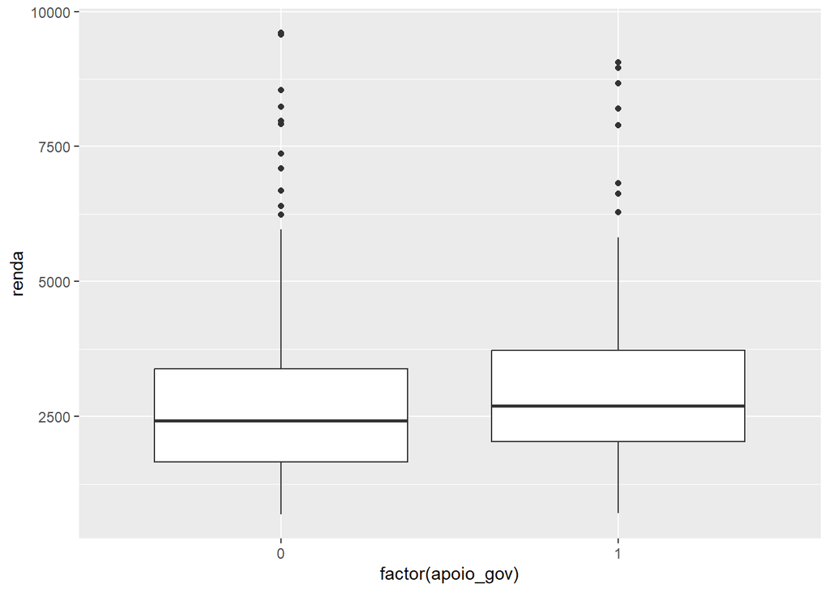

```r
ggplot(dados, aes(x = factor(apoio_gov), y = renda)) +
  geom_boxplot()
```

As médias dos grupos que apoiam e não apoiam o governo estão próximas, mas a diferença não é significativa. Portanto, a renda não está associada à aprovação do governo.

# EXERCICIO 5 – Correlação: renda, ideologia e satisfação com o governo

```r
dados %>%
  select(renda, ideologia, satisf_gov) %>%
  cor(use = "complete.obs")
```

```
##                 renda   ideologia  satisf_gov
## renda      1.00000000  0.02053989  0.59336969
## ideologia  0.02053989  1.00000000 -0.07964692
## satisf_gov 0.59336969 -0.07964692  1.00000000
```

### 1.Renda x ideologia

A correlação é +0.0205, a tendencia é positiva, mas é muito fraca (praticamente nula, r ≈ 0.02), não há associação relevante entre renda e ideologia.

### 2.Renda × Satisfação com o governo

A correlação é +0.5934, a tendencia é positiva e forte (quanto maior a renda, maior tende a ser a satisfação com o governo).

### 3.Ideologia × Satisfação com o governo

A correlação é –0.0796, a tendencia é negativa e fraca (ideologia praticamente não explica satisfação com o governo)

### Construa um gráfico de dispersão de renda (eixo x) por satisf_gov (eixo y), com linha de tendência linear:

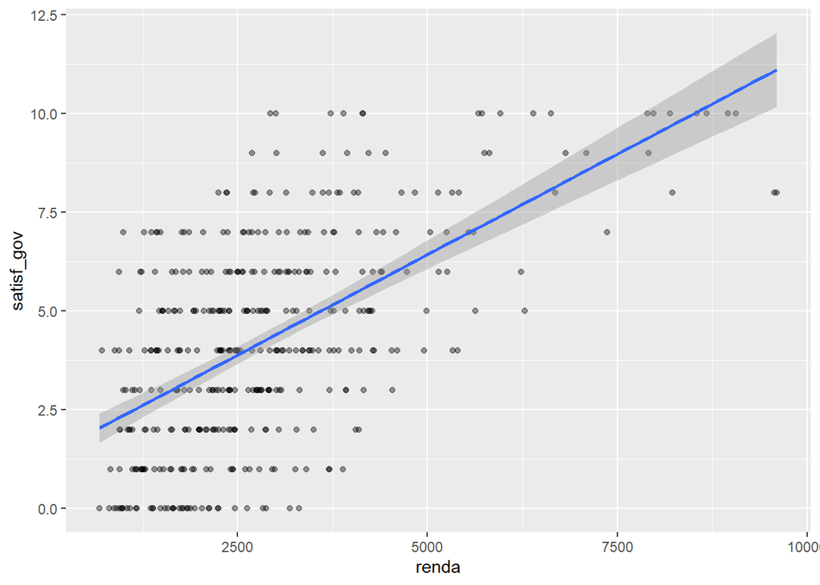

```r
ggplot(dados, aes(x = renda, y = satisf_gov)) +
  geom_point(alpha = 0.4) +
  geom_smooth(method = "lm", se = TRUE)
```

### INTERPRETAÇÃO:

O gráfico confirma visualmente o resultado da correlação: existe uma associação positiva relativamente forte entre renda e satisfação com o governo. A maior renda, as pessoas tendem a ter maior satisfação, embora sempre haja variabilidade individual.

# EXERCICIO 6 - Regressão linear simples: satisfação e renda

```r
mod1 <- lm(satisf_gov ~ renda, data = dados)
summary(mod1)
```

```
##
## Call:
## lm(formula = satisf_gov ~ renda, data = dados)
##
## Residuals:
##     Min      1Q  Median      3Q     Max
## -4.7149 -1.6354 -0.1648  1.5664  5.6727
##
## Coefficients:
##              Estimate Std. Error t value Pr(>|t|)
## (Intercept) 1.346e+00  2.267e-01   5.938  6.3e-09 ***
## renda       1.017e-03  6.917e-05  14.706  < 2e-16 ***
## ---
## Signif. codes:  0 '***' 0.001 '**' 0.01 '*' 0.05 '.' 0.1 ' ' 1
##
## Residual standard error: 2.195 on 398 degrees of freedom
## Multiple R-squared:  0.3521, Adjusted R-squared:  0.3505
## F-statistic: 216.3 on 1 and 398 DF,  p-value: < 2.2e-16
```

# INTERPRETAÇÃO:

El valor del intercepto indica que si la renta se mantiene en las condiciones iniciales, a satisfação com o governo seria, em média, de 1.346 unidades. Cada R$ 1 000 de incremento na renta, a satisfação aumenta em 1,017 puntos. O p-value é praticamente zero, o que significa que a probabilidade de obter um coeficiente semelhante por acaso é quase nula. Portanto, há evidência estatística de que existe uma relação entre a renda e a satisfação com o governo.

```r
#Utilize o broom para obter uma tabela organizada:
tidy(mod1)
```

```
## # A tibble: 2 × 5
##   term        estimate std.error statistic  p.value
##   <chr>          <dbl>     <dbl>     <dbl>    <dbl>
## 1 (Intercept)  1.35    0.227          5.94 6.30e- 9
## 2 renda        0.00102 0.0000692     14.7  2.08e-39
```

A estimativa dá o tamanho do efeito e o Erro‑padrão mede a precisão dessa estimativa. O t muito alto e p‑valores minúsculos indicam significância fortíssima.

## Refaça o gráfico de dispersão com reta de regressão (como no Exercício 5) e escreva um parágrafo relacionando:

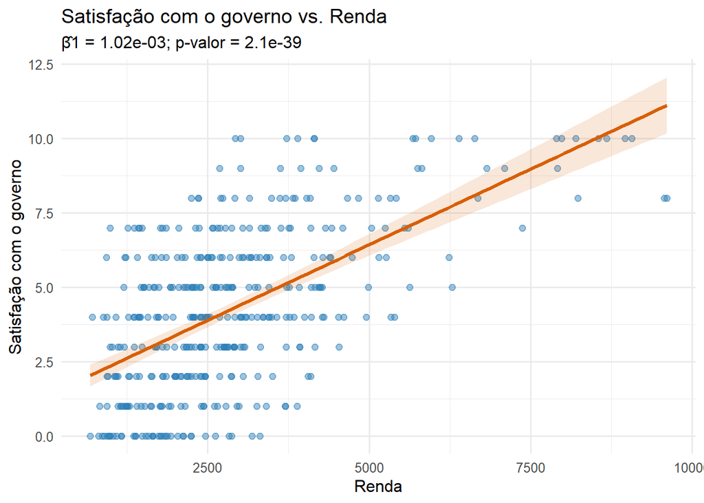

```r
pkgs <- c("ggplot2", "broom", "glue", "dplyr")
to_install <- setdiff(pkgs, rownames(installed.packages()))
if (length(to_install) > 0) install.packages(to_install, dependencies = TRUE)

library(ggplot2)
library(broom)
library(glue)
library(dplyr)

tb <- tidy(mod1)
b1 <- tb %>% filter(term == "renda")

beta1  <- b1$estimate
se1    <- b1$std.error
t1     <- b1$statistic
p1     <- b1$p.value

# Intervalo de confiança (95%)
ic  <- confint(mod1)
ic_l <- ic["renda", 1]
ic_u <- ic["renda", 2]

# Gráfico: dispersão + reta de regressão
ggplot(dados, aes(x = renda, y = satisf_gov)) +
  geom_point(alpha = 0.45, color = "#2C7FB8", size = 2) +
  geom_smooth(method = "lm", se = TRUE, color = "#D95F02",
              fill = "#D95F02", alpha = 0.15) +
  labs(
    title = "Satisfação com o governo vs. Renda",
    subtitle = glue("β̂1 = {format(beta1, digits = 3, scientific = TRUE)}; p-valor = {format(p1, digits = 2, scientific = TRUE)}"),
    x = "Renda",
    y = "Satisfação com o governo"
  ) +
  theme_minimal(base_size = 12)
```

### INTERPRETAÇÃO:

O gráfico mostra uma relação claramente positiva entre renda e satisfação com o governo: à medida que as pessoas têm rendas mais altas, tendem a relatar níveis mais elevados de satisfação. A inclinação da reta (β̂₁ = 0,00102) indica que esse efeito é crescente e consistente, e o valor p extremamente baixo (2,1e−39) revela que a probabilidade de observar esse padrão por acaso é praticamente nula. Portanto, tanto visualmente quanto estatisticamente, a renda é um forte indicador da satisfação com o governo.

# EXERCICIO 7 – Diagnóstico simples do modelo

```r
dados_diag <- augment(mod1)
glimpse(dados_diag)
```

```
## Rows: 400
## Columns: 8
## $ satisf_gov <dbl> 4, 4, 2, 0, 3, 2, 7, 6, 6, 6, 7, 4, 9, 4, 6, 0, 2, 6, 4, 8,…
## $ renda      <dbl> 4277, 2466, 2459, 1171, 3712, 2250, 1800, 1234, 2152, 1635,…
## $ .fitted    <dbl> 5.696488, 3.854315, 3.847195, 2.537024, 5.121763, 3.634597,…
## $ .resid     <dbl> -1.6964884, 0.1456848, -1.8471947, -2.5370241, -2.1217629, …
## $ .hat       <dbl> 0.004473474, 0.002659902, 0.002665529, 0.005357314, 0.00320…
## $ .sigma     <dbl> 2.196038, 2.197683, 2.195734, 2.193984, 2.195106, 2.196159,…
## $ .cooksd    <dbl> 1.348244e-03, 5.890268e-06, 9.489750e-04, 3.617343e-03, 1.5…
## $ .std.resid <dbl> -0.77464598, 0.06646169, -0.84269626, -1.15896373, -0.96821…
```

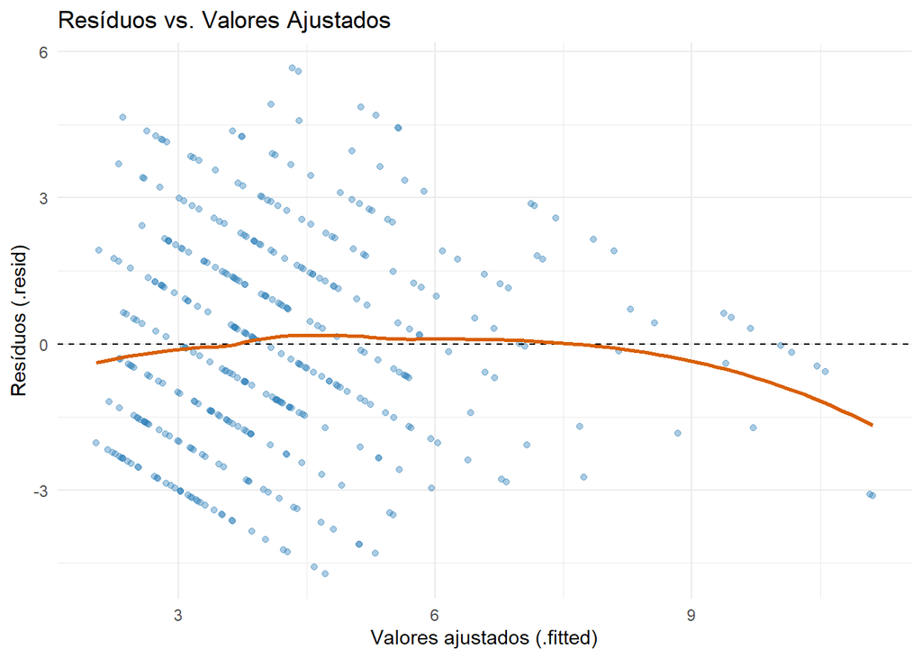

```r
# Construa:
# um gráfico de resíduos vs valores ajustados (.resid vs .fitted)

ggplot(dados_diag, aes(x = .fitted, y = .resid)) +
  geom_point(alpha = 0.4, color = "#2C7FB8") +
  geom_hline(yintercept = 0, linetype = "dashed")+
  geom_smooth(method = "loess", se = FALSE, color = "#D95F02") +
  labs(
    title = "Resíduos vs. Valores Ajustados",
    x = "Valores ajustados (.fitted)",
    y = "Resíduos (.resid)"
  ) +
  theme_minimal()
```

### INTERPRETAÇÃO:

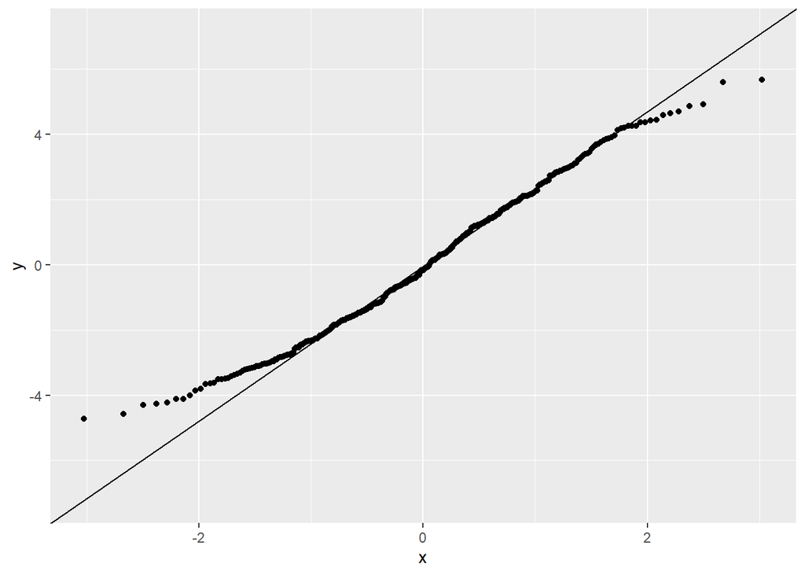

```r
# um gráfico QQ-plot dos resíduos.

ggplot(dados_diag, aes(sample = .resid)) +
  stat_qq() +
  stat_qq_line()
```

A distribuição dos resíduos é aproximadamente normal. Os pontos seguem muito de perto a linha teórica, com apenas desvios leves nas caudas.

### DISCUSSÃO:

Olhar os gráficos de resíduos permite verificar se as suposições do modelo são razoáveis. No campo das políticas públicas, isso é crucial, porque inferências mal‑diagnosticadas podem gerar decisões incorretas, desperdício de recursos e políticas ineficazes.

# EXERCICIO 8 – Regressão com variável dummy e diferença de médias

```r
mod2 <- lm(satisf_gov ~ apoio_gov, data = dados)
summary(mod2)
```

```
##
## Call:
## lm(formula = satisf_gov ~ apoio_gov, data = dados)
##
## Residuals:
##    Min     1Q Median     3Q    Max
## -5.680 -1.680 -0.412  1.588  6.588
##
## Coefficients:
##             Estimate Std. Error t value Pr(>|t|)
## (Intercept)   3.4120     0.1578  21.624   <2e-16 ***
## apoio_gov     2.2680     0.2577   8.802   <2e-16 ***
## ---
## Signif. codes:  0 '***' 0.001 '**' 0.01 '*' 0.05 '.' 0.1 ' ' 1
##
## Residual standard error: 2.495 on 398 degrees of freedom
## Multiple R-squared:  0.1629, Adjusted R-squared:  0.1608
## F-statistic: 77.48 on 1 and 398 DF,  p-value: < 2.2e-16
```

```r
# Coeficientes, SE, t, p
tidy(mod2)
```

```
## # A tibble: 2 × 5
##   term        estimate std.error statistic  p.value
##   <chr>          <dbl>     <dbl>     <dbl>    <dbl>
## 1 (Intercept)     3.41     0.158     21.6  3.84e-69
## 2 apoio_gov       2.27     0.258      8.80 4.15e-17
```

```r
confint(mod2)  # IC 95% (assumindo homocedasticidade)
```

```
##                2.5 %   97.5 %
## (Intercept) 3.101801 3.722199
## apoio_gov   1.761447 2.774553
```

```r
# Calcule as médias de satisf_gov nos dois grupos (apoio_gov = 0 e apoio_gov = 1)
# e compare com os coeficientes de mod2.

    dados <- dados |>
      mutate(apoio_gov = factor(apoio_gov, levels = c(0,1),
                                labels = c("Não apoia","Apoia")))

    # Médias por grupo
    resumo_grupos <- dados |>
      group_by(apoio_gov) |>
      summarise(n = n(),
                media = mean(satisf_gov, na.rm = TRUE),
                sd = sd(satisf_gov, na.rm = TRUE),
                .groups = "drop")
    resumo_grupos
```

```
## # A tibble: 2 × 4
##   apoio_gov     n media    sd
##   <fct>     <int> <dbl> <dbl>
## 1 Não apoia   250  3.41  2.55
## 2 Apoia       150  5.68  2.39
```

```r
    # Diferenca de médias "na mão"
    diff(resumo_grupos$media) # (Apoia - Não apoia)
```

```
## [1] 2.268
```

A diferença entre os dois grupos é 2,27. Ao comparar com os coeficientes do mod2, observa-se que o coeficiente da interceptação é igual à média do grupo que não apoia o governo, e o coeficiente β^1 é igual ao valor da diferença das medias dos dois grupos.

```r
# Aplique
    t.test(satisf_gov ~ apoio_gov, data = dados, var.equal = TRUE)
```

```
##
##  Two Sample t-test
##
## data:  satisf_gov by apoio_gov
## t = -8.8022, df = 398, p-value < 2.2e-16
## alternative hypothesis: true difference in means between group Não apoia and group Apoia is not equal to 0
## 95 percent confidence interval:
##  -2.774553 -1.761447
## sample estimates:
## mean in group Não apoia     mean in group Apoia
##                   3.412                   5.680
```

#### Compare o valor-p de apoio_gov no summary(mod2) com o valor-p do t.test.Em texto, discuta a relação entre os dois resultados.

```r
summary(mod2)
```

```
##
## Call:
## lm(formula = satisf_gov ~ apoio_gov, data = dados)
##
## Residuals:
##    Min     1Q Median     3Q    Max
## -5.680 -1.680 -0.412  1.588  6.588
##
## Coefficients:
##             Estimate Std. Error t value Pr(>|t|)
## (Intercept)   3.4120     0.1578  21.624   <2e-16 ***
## apoio_gov     2.2680     0.2577   8.802   <2e-16 ***
## ---
## Signif. codes:  0 '***' 0.001 '**' 0.01 '*' 0.05 '.' 0.1 ' ' 1
##
## Residual standard error: 2.495 on 398 degrees of freedom
## Multiple R-squared:  0.1629, Adjusted R-squared:  0.1608
## F-statistic: 77.48 on 1 and 398 DF,  p-value: < 2.2e-16
```

O valor-p de apoio_gov no summary(mod2) com o valor-p do t.test coincidem, porque ambos estão testando a mesma diferença de médias com a mesma variância agrupada e os mesmos graus de liberdade; por isso, o t e o valor p são iguais.